# Project 3 - Section 1

Team 1

March 23, 2016

## 4. Visualization and Analysis

### a. Visualization and Graphs

When we examined the data, we found the the skill names are weighted on different scales and that the top Data Science Skills are different for the 3 sources.

```r
skilldb <- dbConnect(MySQL(), user=proj_user, password=proj_pwd, dbname=proj_db, host=proj_host)
weightedskills <- dbGetQuery(skilldb, "select * from tbl_data")
```

include all R packages needed for visualization of results

```r
library(tidyr)
library(dplyr)
library(ggplot2)
library(RColorBrewer)
library(knitr)
```

convert columns to proper data type, pick relevant columns and arrange by source

```r
weightedskills$skill_name <- as.character(weightedskills$skill_name)
weightedskills$weighted_rating_overall <- as.numeric(weightedskills$weighted_rating_overall)
weightedskills$source_name <- as.character(weightedskills$source_name)

weightedskills1 <- weightedskills %>%
                   select(skill_name, weighted_rating_overall, source_name) %>%
                   arrange(source_name)
```

convert vector to a data frame

```r
weightedskills1 <- data.frame(weightedskills1)
```

pick all rows that have a Google source

```r
weightedskills11 <- filter(weightedskills1, source_name == "Google")
weightedskills11 <- weightedskills11[order(-weightedskills11$weighted_rating_overall),]
```

pick the top six Google data science skills and generate bar graph

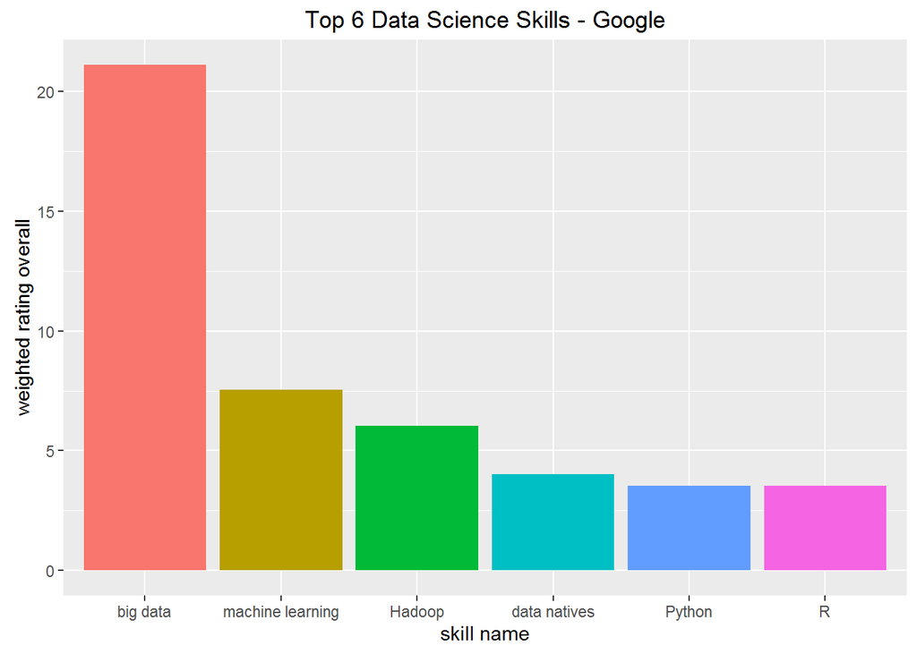

```r
h1 = head(weightedskills11)
p1 = ggplot(h1, aes(y = weighted_rating_overall, fill = skill_name))
h1$skill_name = reorder(h1$skill_name, -h1$weighted_rating_overall)
p1 + geom_bar(aes(x = skill_name), data = h1, stat = "identity") + xlab("skill name") + ylab("weighted rating overall") + theme(legend.position = "none") +
ggtitle("Top 6 Data Science Skills - Google")
```

pick all rows that have a Indeed source

```r
weightedskills12 = filter(weightedskills1, source_name == "Indeed")
weightedskills12 = weightedskills12[order(-weightedskills12$weighted_rating_overall),]
```

pick the top six Indeed data science skills and generate bar graph

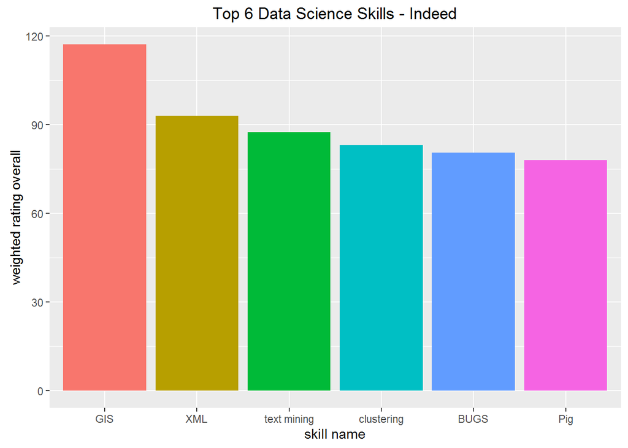

```r
h2 = head(weightedskills12)
p2 = ggplot(h2, aes(y = weighted_rating_overall, fill = skill_name))
h2$skill_name = reorder(h2$skill_name, -h2$weighted_rating_overall)
p2 + geom_bar(aes(x = skill_name), data = h2, stat = "identity") + xlab("skill name") + ylab("weighted rating overall") + theme(legend.position = "none") +
ggtitle("Top 6 Data Science Skills - Indeed")
```

pick all rows that have a Kaggle source

```r
weightedskills13 = filter(weightedskills1, source_name == "Kaggle")
weightedskills13 = weightedskills13[order(-weightedskills13$weighted_rating_overall),]
```

pick the top six Kaggle data science skills and generate bar graph

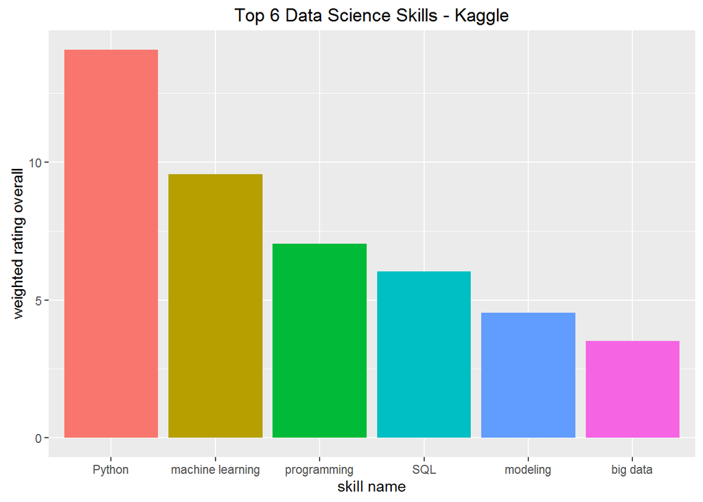

```r
h3 = head(weightedskills13)
p3 = ggplot(h3, aes(y = weighted_rating_overall, fill = skill_name))
h3$skill_name = reorder(h3$skill_name, -h3$weighted_rating_overall)
p3 + geom_bar(aes(x = skill_name), data = h3, stat = "identity") + xlab("skill name") + ylab("weighted rating overall") + theme(legend.position = "none") +
ggtitle("Top 6 Data Science Skills - Kaggle")
```

#### 2. Horizontal Bar Graph Showing the Top 20 Data Science Skills from the 3 Sources (Google, Indeed and Kaggle)

read data

```r
jobdata <- read.csv("https://raw.githubusercontent.com/danielhong98/MSDA-Spring-2016/347a383eae3b9f02bc5d128efb5de14e1f688f8e/tbl_data_v2.csv")
```

order by source_name (asc) and weighted_rating_overall

```r
newjobdata <- jobdata[with(jobdata, order(source_name,-weighted_rating_overall)),]
```

list skill_name for each source_name

```r
Google <- subset(newjobdata, source_name == "Google", select=c(source_name, skill_name,weighted_rating_overall))
Google <- Google[c(1:20),]
Indeed <- subset(newjobdata, source_name == "Indeed", select=c(source_name, skill_name, weighted_rating_overall))
Indeed <- Indeed[c(1:20),]
Kaggle <- subset(newjobdata, source_name == "Kaggle", select=c(source_name, skill_name, weighted_rating_overall))
Kaggle <- Kaggle[c(1:20),]
Combined <- cbind(Google,Indeed,Kaggle)
Combined$source_name <- NULL
Combined$source_name <- NULL
Combined$source_name <- NULL
colnames(Combined)[1] <- "GoogleSkills"
colnames(Combined)[2] <- "GoogleRatings"
colnames(Combined)[3] <- "IndeedSkills"
colnames(Combined)[4] <- "IndeedRatings"
colnames(Combined)[5] <- "KaggleSkills"
colnames(Combined)[6] <- "KaggleRatings"
kable(Combined)
```

|  | GoogleSkills | GoogleRatings | IndeedSkills | IndeedRatings | KaggleSkills | KaggleRatings |
| --- | --- | --- | --- | --- | --- | --- |
| 13 | big data | 21.128834 | GIS | 117.21472 | Python | 14.0858896 |
| 24 | machine learning | 7.546012 | XML | 93.06748 | machine learning | 9.5582822 |
| 21 | Hadoop | 6.036810 | text mining | 87.53374 | programming | 7.0429448 |
| 17 | data natives | 4.024540 | clustering | 83.00614 | SQL | 6.0368098 |
| 29 | Python | 3.521472 | BUGS | 80.49080 | modeling | 4.5276074 |
| 30 | R | 3.521472 | Pig | 77.97546 | big data | 3.5214724 |
| 34 | SQL | 3.018405 | JSON | 73.44785 | Hadoop | 3.0184049 |
| 28 | NOSQL | 2.515337 | SVM | 72.44172 | Java | 3.0184049 |
| 15 | data engineering | 2.012270 | DBA | 71.93865 | analytics | 2.9631902 |
| 16 | data mining | 1.509203 | ANOVA | 69.42331 | business | 1.7177914 |
| 86 | analytics | 1.417178 | Simulation | 68.41718 | statistics | 1.6748466 |
| 107 | analysis | 1.226994 | Rails | 66.40491 | MATLAB | 1.5092025 |
| 111 | information | 1.104294 | Objective C | 64.89571 | predictive analytics | 1.5092025 |
| 14 | cloud | 1.006135 | Teradata | 63.88957 | SAS | 1.5092025 |
| 18 | devops | 1.006135 | PostgreSQL | 62.38037 | team | 0.7730061 |
| 19 | fintech | 1.006135 | SPSS | 61.37423 | communication | 0.6073620 |
| 20 | galaxql | 1.006135 | Oracle | 60.87117 | R | 0.5030675 |
| 22 | IOS | 1.006135 | MySQL | 57.34969 | interpersonal | 0.4969325 |
| 23 | Java | 1.006135 | MATLAB | 54.33129 | management | 0.4969325 |
| 25 | MATLAB | 1.006135 | Stata | 53.82822 | research | 0.4907975 |

plot results

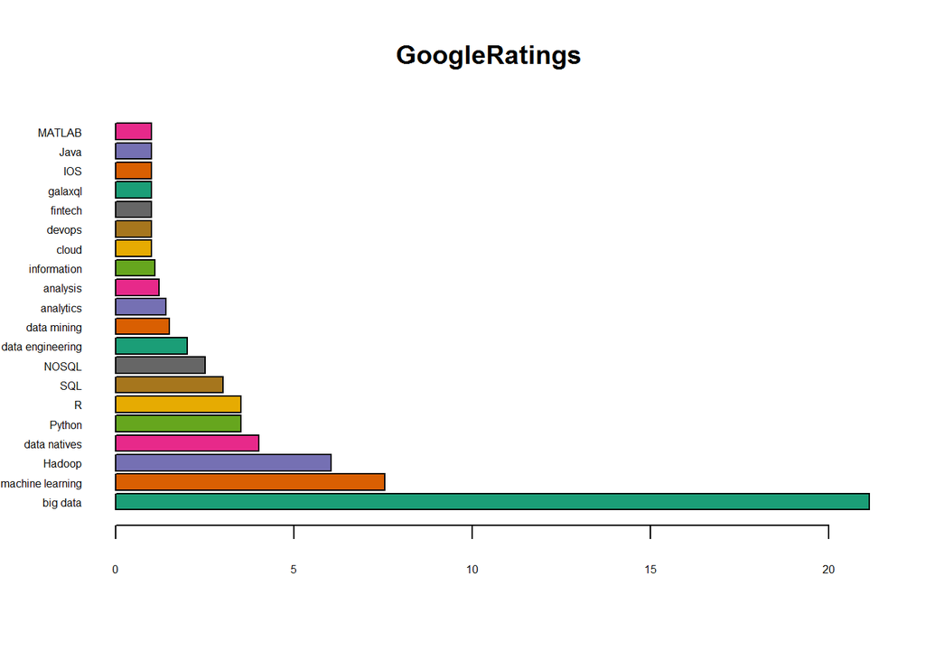

```r
darkcols <- brewer.pal(8,"Dark2")
names <- Combined$GoogleSkills
barplot(Combined$GoogleRatings,main="GoogleRatings", horiz=TRUE, names.arg=names, las=1, col=darkcols, cex.axis=0.5, cex.names = 0.5)
```

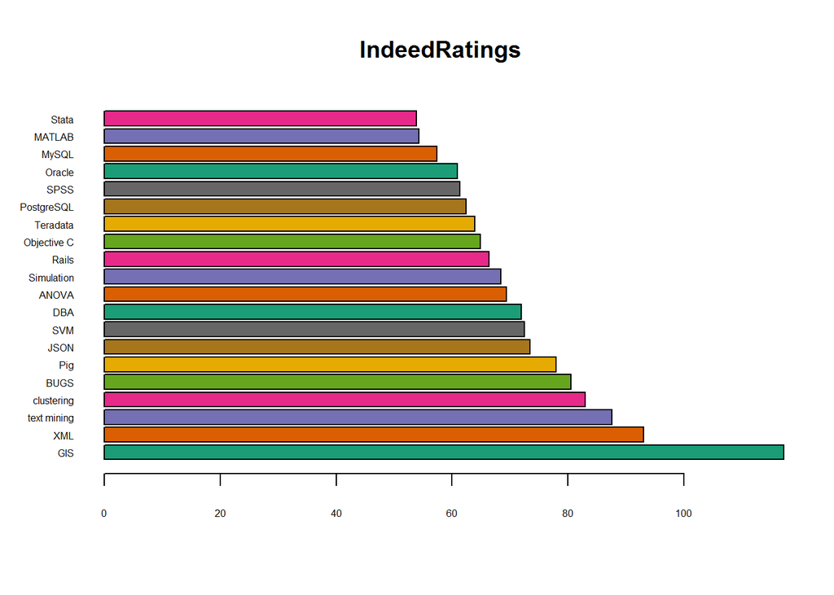

```r
names <- Combined$IndeedSkills
barplot(Combined$IndeedRatings,main="IndeedRatings", horiz=TRUE, names.arg=names, las=1, col=darkcols, cex.axis=0.5, cex.names = 0.5)
```

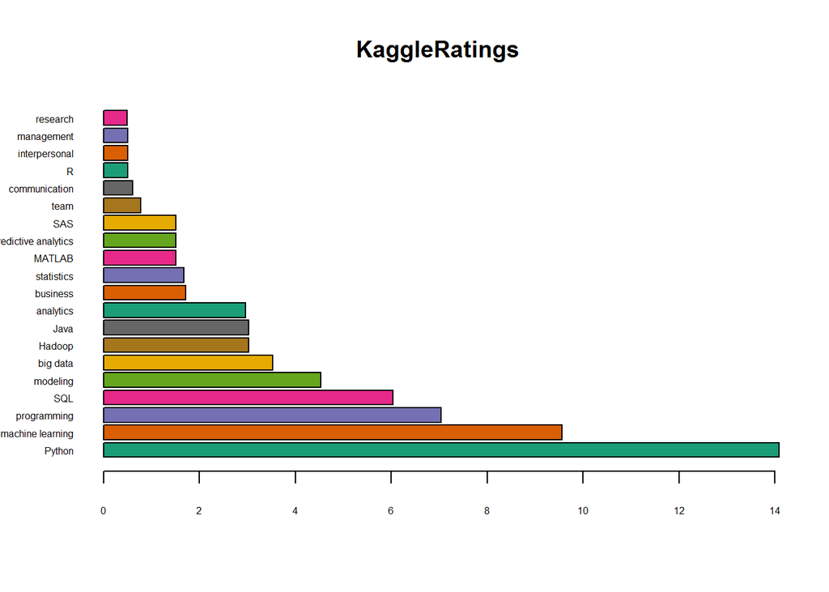

```r
names <- Combined$KaggleSkills
barplot(Combined$KaggleRatings,main="KaggleRatings", horiz=TRUE, names.arg=names, las=1, col=darkcols, cex.axis=0.5, cex.names = 0.5)
```

#### 3. Bubble Graph Showing Weighted Rank of Skills by Skill Type and Source (Google, Indeed and Kaggle)

```r
data<- read.csv("https://raw.githubusercontent.com/ChristopheHunt/MSDA---Coursework/master/Data%20607/Homework/Group%20Project/tbl_data_version1%20.csv")
```

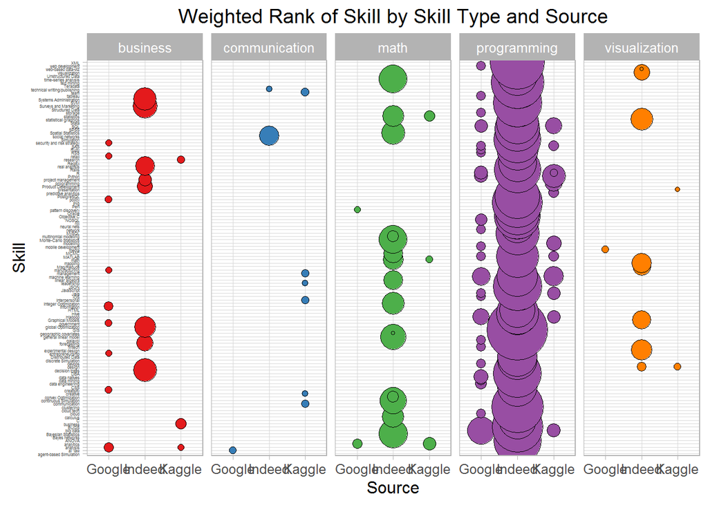

```r
ggplot(data, aes(source_name, skill_name, label = skill_name,
                    size = weighted_rating_overall, fill = skill_type_name)) +
        geom_point(pch = 21) +
        scale_fill_manual(values =  brewer.pal(9, "Set1")) +
        scale_size_continuous(range =c(1,20)) +
        facet_grid(~skill_type_name) +
        theme_light() +
        xlab("Source") +
        ylab("Skill") +
        theme(legend.position = "none" , axis.text.y = element_text(size=3)) +
        ggtitle("Weighted Rank of Skill by Skill Type and Source")
```

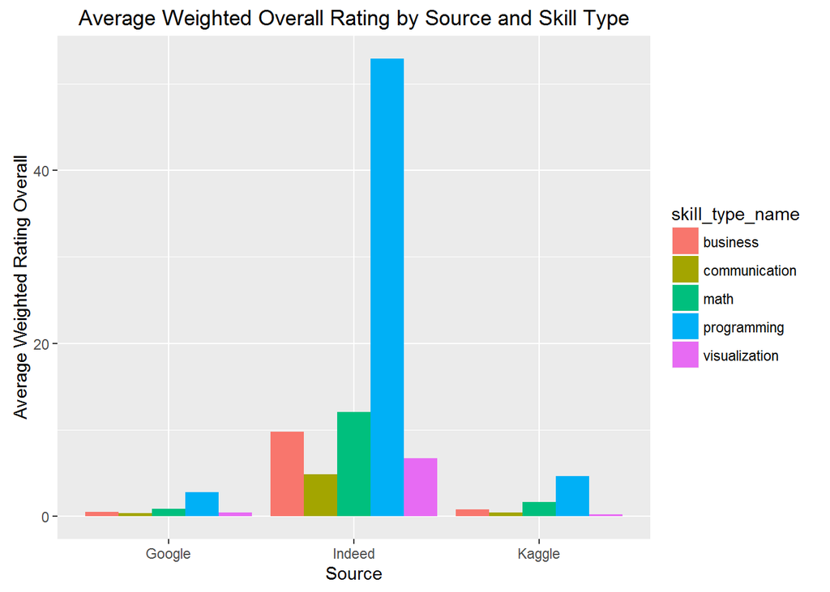

```r
stab <- data %>% group_by(source_name,skill_type_name) %>% summarise(ave_wgt =mean(weighted_rating_overall))

ggplot(stab, aes(x =source_name, y=round(ave_wgt,2), fill = skill_type_name)) +  geom_bar(stat="identity",position="dodge") + xlab("Source") + ylab("Average Weighted Rating Overall") + ggtitle("Average Weighted Overall Rating by Source and Skill Type")
```